# Big Data : une mine d’or pour innover dans l’agroalimentaire

Données & I.A.

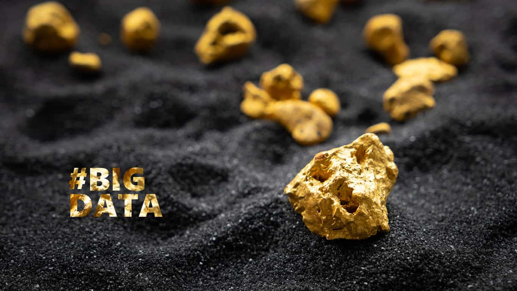

28 septembre 2021

Quelle transformation numérique pour l’industrie agroalimentaire ? C’est par cette question que nous pourrions résumer l’atelier « Big Data : une mine d’or à exploiter pour innover en agroalimentaire ! » organisé par le pôle de compétitive [Valorial](https://www.pole-valorial.fr/). En effet, après une introduction générale sur le Big Data, la discussion a rapidement débordé sur des enjeux purement business : expérience utilisateur, connaissance client, désintermédiation, chaîne de valeur, réduction des coûts…

Le Big Data c’est le constat relativement simple que nos actions (numériques) quotidiennes produisent des data : nos achats, nos consultations, nos lectures sur écran, nos emails, nos transactions, nos profils, nos commentaires, nos photos et nos likes produisent des data… que cela soit en tant que consommateur, qu’individu, que citoyen, ou bien en tant que collaborateur à l’intérieur d’une organisation.

Précision lexicale : Nous utilisons volontairement le terme anglais data plutôt que le terme français «données», car ce dernier pourrait, du fait de l’homonymie, laisser croire que les données sont données alors même qu’elles sont construites !

**Votre entreprise évolue dans le secteur agroalimentaire ? Découvrez notre webinaire :**

[Retour d’expérience : L’intelligence artificielle dans l’agroalimentaire](https://www.isatech.fr/webinaire-intelligence-artificielle-en-agroalimentaire/)

## Capteurs de l’internet des objets

A nos activités humaines intermédiées par des machines, il faut désormais ajouter toutes les [machines connectées](https://www.isatech.fr/agroalimentaire-usine-intelligente-iot/) et les capteurs de l’internet des objets. La production massive des composants utilisés pour les smartphones entraîne une baisse significative des prix, qui font qu’il devient tout à fait raisonnable d’adjoindre à n’importe quel équipement un capteur connecté.

Enfin, ajoutons à cela l’activité continue des [logiciels ERP](https://www.isatech.fr/integrateur-erp/) qui enregistrent l’activité des chaines de production, et des bases de données qui stockent par exemple les éléments de traçabilité et de sécurité sanitaire.

## Le cloud ou la disponibilité en instantanée

Si les datas sont volumineuses, elles sont également disponibles. Et oui, avec le Cloud, oubliées les bandes magnétiques et leurs heures de délais de traitement et de recherche. Tout devient disponible instantanément.

Autre élément abordé lors de cet atelier, si l’accumulation de data permet de suivre ce qu’il s’est réellement passé, et donc de faire du reporting et de prendre les mesures correctives, le temps réel permet désormais de passer au stade supérieur pour suivre ce qui se passe dans l’instant et réaliser un monitoring. La dernière avancée, avec le machine learning, est à présent de rendre accessible au plus grand nombre l’analyse prédictive, afin de projeter ce qui pourra se passer dans l’avenir comme une panne sur une chaîne de production par exemple. Ces technologies de maintenance prédictive sont déjà déployées entre autres par les ascensoristes.

**Lire aussi** : [Comment intégrer son ERP dans le cloud ?](https://www.isatech.fr/comment-integrer-son-erp-dans-le-cloud/)

## Big data : plus c’est gros plus c’est beau ?

C’est l’un des biais récurrent dans le Big Data, la seule accumulation de data permettrait la production de connaissance. Sans vouloir « jeter le bébé avec l’eau du bain», il faut rester prudent, car depuis 30 ans, et l’accumulation par la GMS (grande et moyenne surface) des fameuses cartes de fidélité… aucune nouvelle connaissance n’est réellement sortie de ces datawarehouses.

Oui, mais les choses ont bien changé et les seules données transactionnelles (sortie de caisse) sont d’une terrible pauvreté. Ce n’est pas pour rien que des acteurs de la distribution comme Carrefour proposent désormais le wifi gratuitement des leurs propres rayons. Mais pourquoi diable leur donner la possibilité de comparer les prix ? Tout simplement parce qu’il est plus intéressant via le wifi de suivre précisément le parcours du client en magasin.

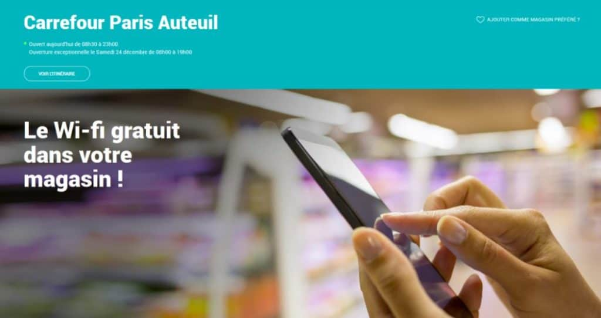

## La big data pour mieux connaître les habitudes des consommateurs

Au cours des échanges de cette journée, qui regroupait essentiellement du personnel R&D et des qualiticiens de l’[industrie agro-alimentaire](https://www.isatech.fr/expertise/agroalimentaire/), deux dimensions sont particulièrement ressorties :

- Comment la big data peut me permettre de mieux connaitre les consommateurs de mes produits alimentaires
- Dans une stratégie plus défensive des IAA, comment la big data peut m’aider à optimiser mes marges ?
- La big data pour mieux connaitre les consommateurs

Qu’il s’agisse de fidéliser ou de conquérir de nouveaux marchés, la connaissance des consommateurs est bien le principal point de faiblesse de l’industrie agro-alimentaire. Et tout particulièrement lorsqu’elle travaille essentiellement avec la GMS. L’industrie ne connait les consommateurs de ses produits qu’au travers d’études de marchés et de panels coûteux et dont on se pose encore la question de l’efficience.

## Comment récupérer de la data sur les consommateurs ?

Or pour proposer une expérience utilisateur unique, novatrice, à valeur ajoutée, il est essentiel de bien connaitre les personnes à qui l’on s’adresse. Mais alors comment récolter de la data sur mes consommateurs ? Il existe de nombreuses options telle que :

- la vente directe en ligne
- le service consommateur
- l’observation des discours sur la marque et les produits en ligne
- les boutiques de franchise
- les programmes de fidélité,
- les extensions de garantie,
- les jeux concours…

Autant d’opportunités d’établir et d’entretenir une relation avec les consommateurs.

## Optimiser ses marges avec la big data

La transformation digitale de l’industrie apporte différentes solutions. Nous l’avons vu, l’internet des objets couplé à la maintenance prédictive permet d’anticiper les pannes et d’accroître la disponibilité des lignes de production.

Pour certains industriels d’autres sources d’économie résident dans la moindre consommation des matières premiers ou de l’énergie. Les bases de données spécialisées, l’archivage des tests et des essais permettent désormais de simuler de nouvelles recettes. Mais aussi de tester virtuellement de nouveaux produits plus rapidement et pour des coûts de revient moindres.

Dans tous les cas, face à cette explosion des data, et pour un peu que vous souhaitiez réellement en tirer des connaissances, voire même de la valeur, il convient de les aborder avec le bon outillage et les bonnes méthodes. Pour cela les domaines de l’[intelligence artificielle](https://www.isatech.fr/avantage-intelligence-artificielle-ia/), mais surtout de la [Business Intelligence](https://www.isatech.fr/expertise/applications-metiers/power-bi/) peuvent constituer de sacrés atouts pour bien commencer.

**Votre entreprise évolue dans le secteur agroalimentaire ? Découvrez notre webinaire :**

[Retour d’expérience : L’intelligence artificielle dans l’agroalimentaire](https://www.isatech.fr/webinaire-intelligence-artificielle-en-agroalimentaire/)

**Simon Le Bayon, PhD**  
*Consultant en stratégie digitale*

par **Simon Le Bayon**

Partager cet article

### Articles récents

[figure not shown]

### Ressources à télécharger

[figure not shown]